# Tallest Buildings

```r
library(magrittr)
library(knitr)
library(plyr)
library(dplyr)
library(tidyr)
```

```r
library(ggplot2)
```

In order to access the data file, I used the following code. This code set the dataset name to “TB” and allows me to use the designation “TB” to refer to the data set in any future code.

```r
TB<-read.csv("tallestbuildings.csv")
```

Now that the dataset has been accessed and been designated to the reference “TB”, it is possible to look at how the data is arranged. The code below allows me to see what the headings are for each collum as well as the first six data variables in each column.

```r
head(TB)
```

```
##   Rank                   Building.Name                  City Height..m.
## 1    1                    Burj Khalifa         Dubai\xff(AE)      828.0
## 2    2                  Shanghai Tower      Shanghai\xff(CN)      632.0
## 3    3        Makkah Royal Clock Tower         Mecca\xff(SA)      601.0
## 4    4          One World Trade Center New York City\xff(US)      541.3
## 5    5                      TAIPEI 101        Taipei\xff(TW)      508.0
## 6    6 Shanghai World Financial Center      Shanghai\xff(CN)      492.0
##   Height..ft. Floors Completed       Material                          Use
## 1       2,717    163      2010 steel/concrete office / residential / hotel
## 2       2,073    128      2015      composite               hotel / office
## 3       1,972    120      2012 steel/concrete                other / hotel
## 4       1,776     94      2014      composite                       office
## 5       1,667    101      2004      composite                       office
## 6       1,614    101      2008      composite               hotel / office
```

```r
summary(TB)
```

```
##       Rank                   Building.Name                    City
##  Min.   :  1.00   23 Marina         : 1    Dubai<ff>(AE)        :18
##  1st Qu.: 25.75   432 Park Avenue   : 1    New York City<ff>(US): 7
##  Median : 50.50   ADNOC Headquarters: 1    Chicago<ff>(US)      : 6
##  Mean   : 50.45   Al Hamra Tower    : 1    Guangzhou<ff>(CN)    : 6
##  3rd Qu.: 75.25   Al Yaqoub Tower   : 1    Hong Kong<ff>(CN)    : 6
##  Max.   :100.00   Almas Tower       : 1    Abu Dhabi<ff>(AE)    : 4
##                   (Other)           :94    (Other)              :53
##    Height..m.     Height..ft.     Floors         Completed
##  Min.   :301.8   994    : 4   Min.   : 41.00   Min.   :1930
##  1st Qu.:308.6   1,004  : 3   1st Qu.: 68.00   1st Qu.:2002
##  Median :329.3   1,076  : 3   Median : 73.00   Median :2011
##  Mean   :358.6   1,112  : 3   Mean   : 77.02   Mean   :2005
##  3rd Qu.:380.6   997    : 3   3rd Qu.: 85.00   3rd Qu.:2014
##  Max.   :828.0   1,002  : 2   Max.   :163.00   Max.   :2016
##                  (Other):82
##            Material                            Use
##  composite     :49   office                      :39
##  concrete      :35   hotel / office              :18
##  concrete/steel: 1   residential                 :13
##  steel         :10   hotel                       : 7
##  steel/concrete: 5   residential / hotel         : 6
##                      residential / hotel / office: 5
##                      (Other)                     :12
```

## Arranging the Cities

The first thing to do in this data set is to seperate the City variable into two new variables. It is important to notice that in the data, the varaibles are writen in the manner “city(country)”. We can seperate this at the into a first variable, the city, and the second variable, the country. The seperate function below will do the trick!

```r
TB=TB%>%separate(City, c("City","Country"), sep = "\xff")
```

Now that we have seperated the Cities from the Countries, we can graph the Cities into a bar graph. We do this through the following funtion:

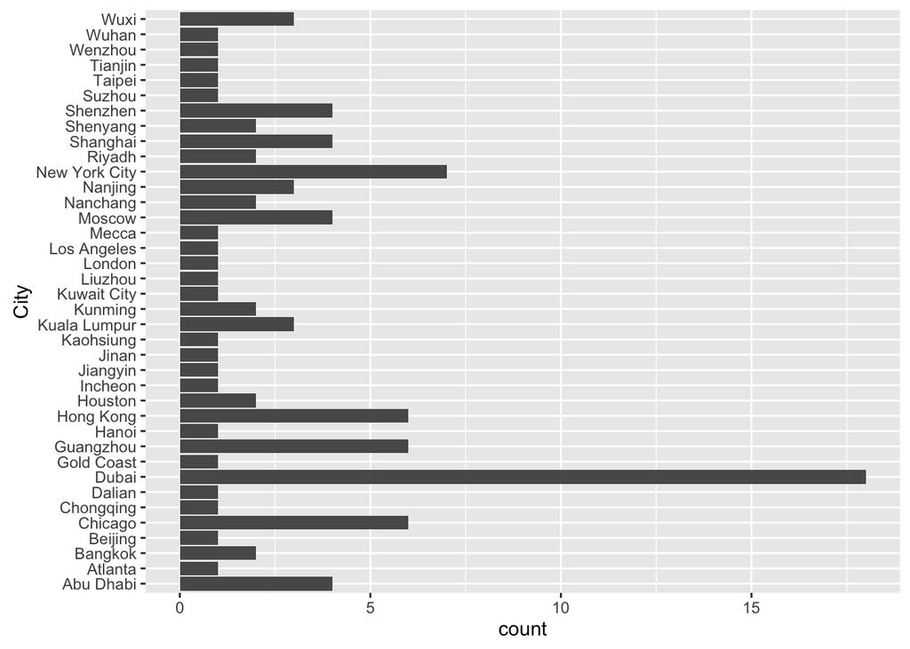

```r
ggplot(TB, aes(City)) + geom_bar(stat = "count") + coord_flip()
```

Notice that the bar graph is not in ascending order. Putting the graph in ascending order will be very useful in the long run since it allows us to see in an easier manner which city has the most buildings.

```r
Citynumber=TB%>%group_by(City) %>% summarise(count=length(City))
```

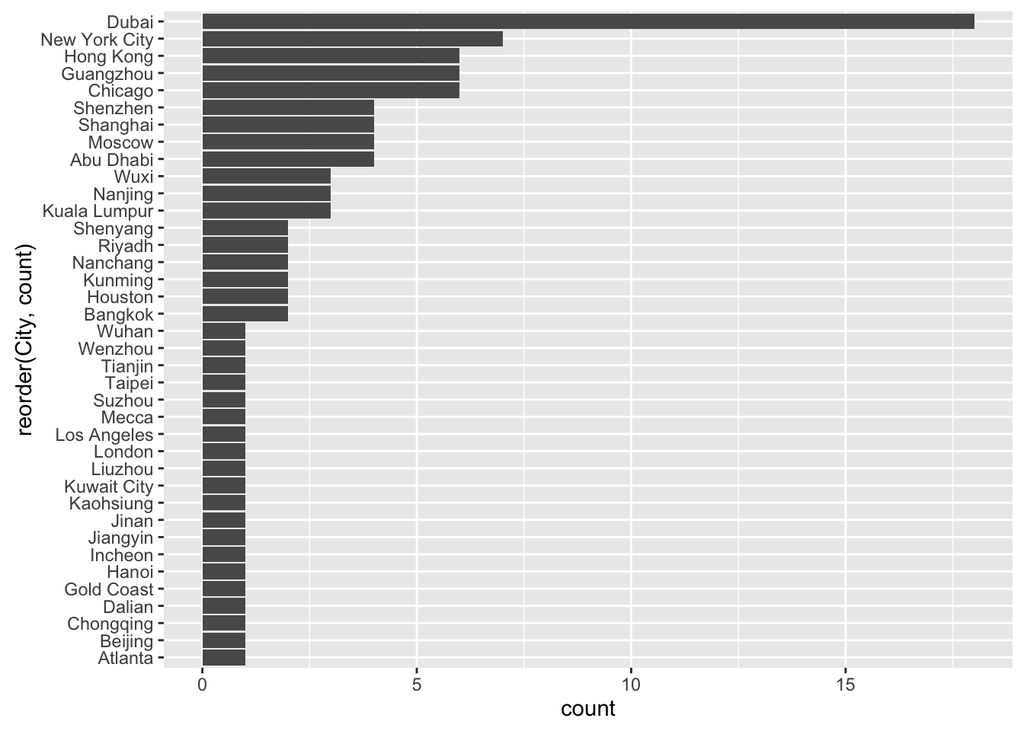

```r
ggplot(Citynumber,aes(x=reorder(City,count),y=count))+geom_bar(stat="identity")+ coord_flip()
```

There we go! Now we see that Dubai has the most buildings. Just for fun, lets add some color!

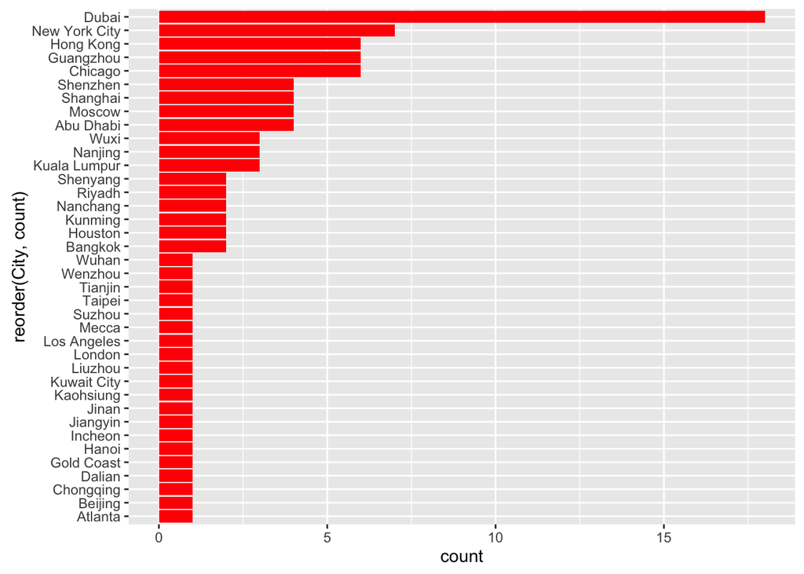

```r
ggplot(Citynumber,aes(x=reorder(City,count),y=count))+geom_bar(stat="identity",fill="Red")+ coord_flip()
```

## Mean Height

Now lets try to find the mean of the buildings in each city. We first do this by grouping the cities with the Height. It is important to recognize that the label is currently “Height..ft.” for the building height in feet. To make this easy, lets just call it “HeightFeet”

```r
TB=rename(TB, HeightFeet=Height..ft.)
```

This column is now labeled “HeightFeet.”

```r
TB%>%group_by(City)
```

```
## Source: local data frame [100 x 10]
## Groups: City [38]
##
##     Rank                   Building.Name          City Country Height..m.
## *  <int>                          <fctr>         <chr>   <chr>      <dbl>
## 1      1                    Burj Khalifa         Dubai    (AE)      828.0
## 2      2                  Shanghai Tower      Shanghai    (CN)      632.0
## 3      3        Makkah Royal Clock Tower         Mecca    (SA)      601.0
## 4      4          One World Trade Center New York City    (US)      541.3
## 5      5                      TAIPEI 101        Taipei    (TW)      508.0
## 6      6 Shanghai World Financial Center      Shanghai    (CN)      492.0
## 7      7   International Commerce Centre     Hong Kong    (CN)      484.0
## 8      8           Petronas Twin Tower 1  Kuala Lumpur    (MY)      451.9
## 9      8           Petronas Twin Tower 2  Kuala Lumpur    (MY)      451.9
## 10    10                    Zifeng Tower       Nanjing    (CN)      450.0
## # ... with 90 more rows, and 5 more variables: HeightFeet <fctr>,
## #   Floors <int>, Completed <int>, Material <fctr>, Use <fctr>
```

As you can see however, for some reason our HeightFeet variables are listed as factors. The reason behind this is due to the fact that the data set contained values with commas in them. This is a common mistake for R aparently and will cause numbers like 1,000 to turn into a factor. Factors cannot have the mean computed since they are on a nominal scale. We need to change the this from a factor to a integer or numeric value. If we try to compute the mean now, we will only get back a “NA.”

So this line of code not only has to convert the factor to a numerical, but must also take into account the numbers without the commas. To do this, we use the as.numerical() function combined with the gsub() function. This allows us to first turn the numbers with commas into numbers without commas and then assign them as a numerical value.

```r
TB$HeightFeet <- as.numeric(gsub(",","",TB$HeightFeet))
```

Now that we have the Height Feet properly converted into means, lets graph our data by grouping them into cities in a descending order.

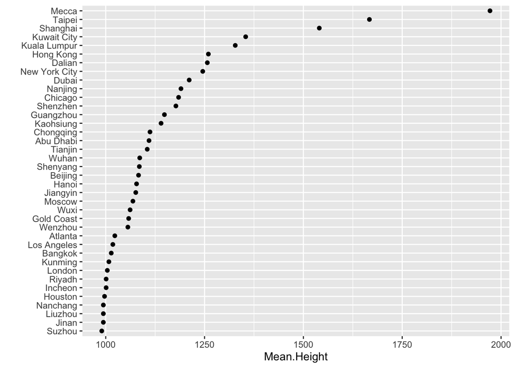

```r
TB%>%group_by(City)%>%
  summarise(Mean.Height=round(mean(HeightFeet),2))%>%ggplot(aes(x=reorder(City,Mean.Height),y=Mean.Height))+geom_point() +xlab("")+coord_flip()
```

## Arranging the Countries

Now that we have already arranged the cities on a bar graph with the number of buildings they have, lets do the same thing but this time with the cournties. We have already separated the Countried from the data set in a previous funtion, so we do not have to do that again. Lets group the by the country!

```r
Countrynumber=TB%>%group_by(Country) %>% summarise(count=length(Country))
```

Now that we have grouped by the country number and saved this as “Countrynumber” we can check on how our table looks after grouping by the country.

```r
head(Countrynumber)
```

```
## # A tibble: 6 × 2
##   Country count
##     <chr> <int>
## 1    (AE)    22
## 2    (AU)     1
## 3    (CN)    42
## 4    (GB)     1
## 5    (KR)     1
## 6    (KW)     1
```

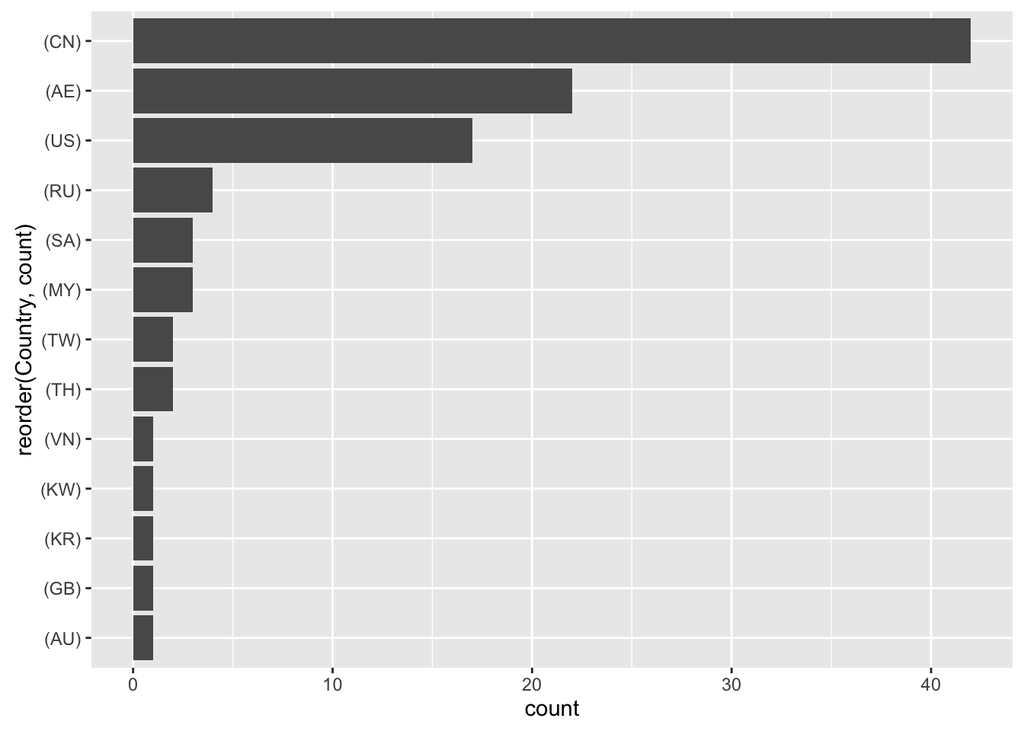

```r
ggplot(Countrynumber,aes(x=reorder(Country,count),y=count))+geom_bar(stat="identity")+ coord_flip()
```

As you can see we now have successfully graphed the Countried in order of the number of buildings they contain. We can clearly see that (CN) contains the most buildings from our list… What is CN you ask? Good question! Country codes like this are sometimes confusing and hard to understand. We can use the countrycode package to fix this problem. First download the package with:

```r
library(countrycode)
```

Now that we have the package, we can use it to convert our country codes into the proper country names. We use iso2c as the origin due to the fact that the country codes we currently see on our dataset are the two digit international standards codes. Country.name is used as the destination since we would like to see the entire name of the country our code is referring to. We also use a gsub again in order to get rid of the () parenthesis around our country codes. This allows the country code function to only read the country codes themselves and not the perenthesis.

```r
Countrynumber$Country<-countrycode(gsub("\\(|\\)","",Countrynumber$Country),"iso2c","country.name")
```

Great! Now that we have converted the country codes into the country names, lets try graphing once more.

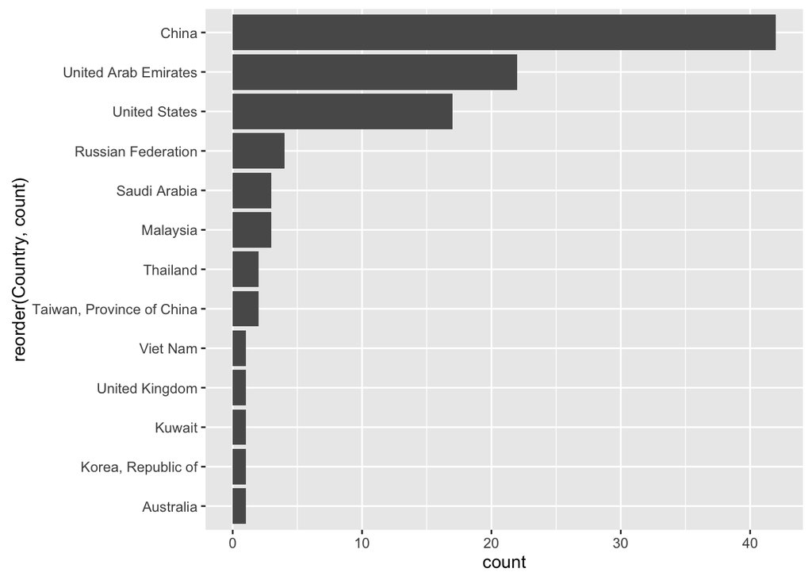

```r
ggplot(Countrynumber,aes(x=reorder(Country,count),y=count))+geom_bar(stat="identity")+ coord_flip()
```

As we can see, (CN) turned out to be China. Lets make our bargraph colorful for one last touch.

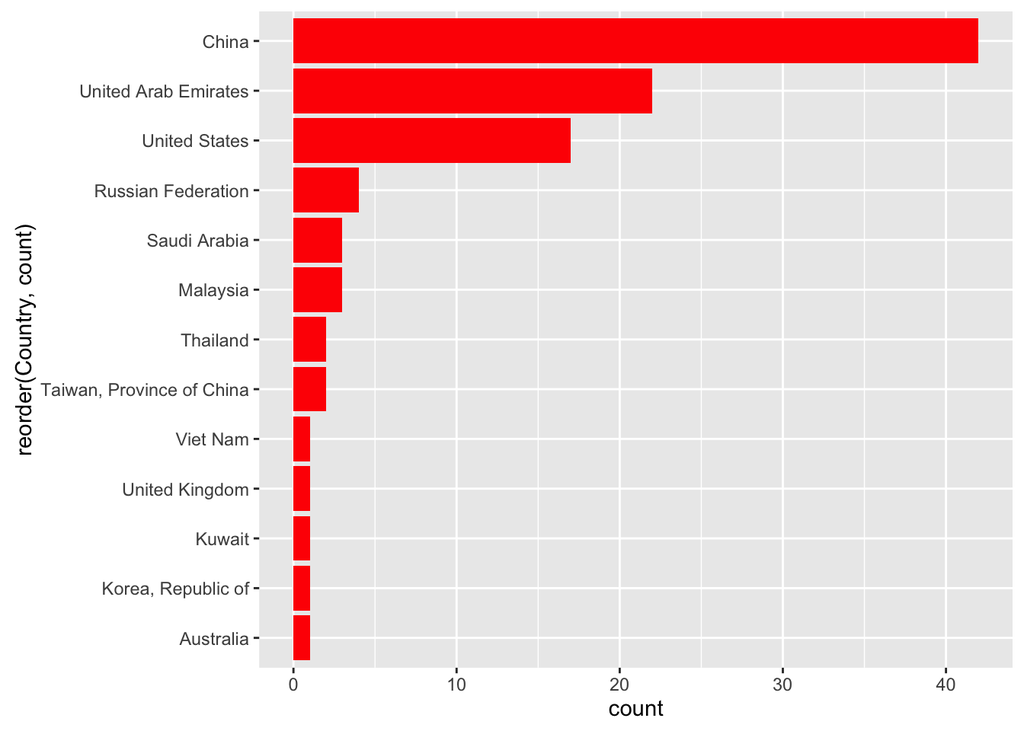

```r
ggplot(Countrynumber,aes(x=reorder(Country,count),y=count))+geom_bar(stat="identity",fill="red")+ coord_flip()
```

## Mean Height of Country

We already did the mean height of buildings in each city, but now lets instead do that with the countries in a bar graph.

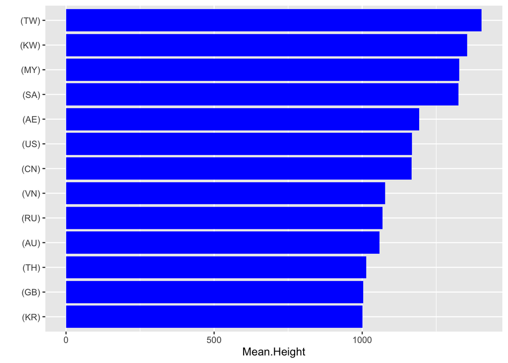

```r
TB%>%group_by(Country)%>%
  summarise(Mean.Height=round(mean(HeightFeet),2))%>%ggplot(aes(x=reorder(Country,Mean.Height),y=Mean.Height))+geom_bar(stat="identity",fill="Blue")+coord_flip()+xlab("")+coord_flip()
```

## Mean Heights of Use

This time, we will look at the mean heights based on the intended use of a building.

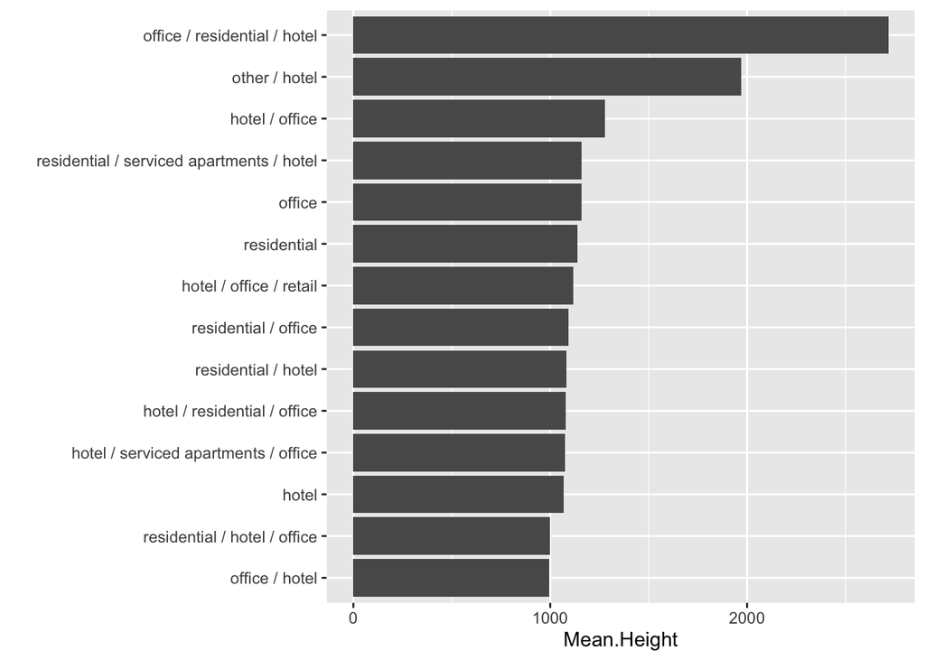

```r
TB%>%group_by(Use)%>%
  summarise(Mean.Height=round(mean(HeightFeet),2))%>%ggplot(aes(x=reorder(Use,Mean.Height),y=Mean.Height),)+geom_bar(stat="identity")+coord_flip() +xlab("")
```